# Studies: First Semester of the Master Year 1

Finally, the lectures start!

LCT Year 1

Published

December 7, 2021

Given that I had to [deferr my admision due to COVID](https://luisavasquez.github.io/quiescens-lct/posts/2021-09-07-lct-acceptance-deferral.html#a-pandemic-of-uncertainty), it was a delight to finally start the lectures in person.

After [activating my University account](https://luisavasquez.github.io/quiescens-lct/posts/2021-11-02-registering_university_lorraine.html#university-account-activation) I got access to the [online platforms of the University](https://luisavasquez.github.io/quiescens-lct/posts/2021-11-05-uni_lorraine_platforms.html), where I could find the calendar for when and where the lectures were going to start.

# Welcome lecture

The first lecture ever was at the [IDMC](https://idmc.univ-lorraine.fr/):

[interactive chart not shown]

The first lecture was a Welcome session led by the **Year 1 Coordinator**, who was very friendly and started explaining us the overall structure of the Master and the University.

There was an important clarification: there are four Coordinator offices involved in this Master: 1. The Year 1 Coordinator 2. The Year 2 Coordinator 3. The LCT Coordinator 4. The Administrative Coordinator

After witnessing the French bureaucracy necessary to get into the Master, this should not be surprising at all. As it happens, as of 2021, the Year 2 Coordinator and the LCT Coordinator are the *same* person.

# Meeting everyone

In this first month one can start getting to know the other students, which IMO, are the best part of the Master’s at the University of Lorraine.

People in the Masters are a few from France, half from Europe, and the rest from the rest of the world. During the first month I went through meeting most of my classmates.

This happens at the same time that everyone is still finishing their bureaucracy, figuring out where are the classrooms, how to use the student cantine, how to set up the University Application, what the courses are about, etc. These common issues and worries help in creating rapport among everyone, with the exception being the (majority of the) French students, which always kept to themselves. Later I’d realise that this was a common pattern from French students.

## Student representatives

Some weeks into the Semester it is necessary to choose two student representatives. They communicated with the teachers and coordinators about student issues.

IMO we made a good choice: a native English speaker and a native French speaker. This made communication really smooth.

# Courses

Here you can find a [course-by-course analysis](https://luisavasquez.github.io/quiescens-lct/posts/2021-12-12-first_semester_courses.html) of the semester, however some overall characteristics of the courses were:

- the professor has total decision power over the content *and* organisation of the course, even if there is a published course description. This may contrast with other academic systems (like the UK, USA, Germany…)
- don’t expect to get a syllabus
- classrooms may change every couple of weeks
- expect a final project, an exam, or both
- some courses are shared with students from the [Cognitive Sciences Master](https://idmc.univ-lorraine.fr/courses/master-1-sciences-cognitives/) or from the [Sciences du Langage Master](https://formations.univ-lorraine.fr/fr/master/1736-master-analyse-et-traitement-du-lexique.html)
- the Cognitive Sciences students are very loud
- there will always be some deadline coming
- most courses don’t go deep into the material, instead, they focus on projects and homework: Even if the material is not hard, it is the workload what makes it difficult
- some courses are at the *Campus Lettres et Sciences Humaines* (Humanities Campus), three blocks away from the IDMC

[interactive chart not shown]

# Intense Schedule

There’s a bit of disorganization and overbooking in this semester, so:

> Expect the schedule to change every week!

This is something that the Master should improve for the future: it was really difficult to deal with all the things happening at the same time while not knowing what to expect for each week.

## First month

The schedule for the first month is more loaded than the one for the other months, because it includes a lot of introductory activities:

- some integration activities where people can meet each other
- some one or two session tutorials on tools for the courses (LaTeX, git, linux, etc.)

## *Alternance*

*Alternance* is a French system for students who are working while studying. The class schedule is organized such that one month is full of lectures and the next one is free so that the students can go work. Packaging so many lectures in a month makes it really intense and tiring.

> Due to *Alternance* the schedule during the first semester was from 8AM to 6PM

I’m not going to lie: the *Alternance* schedule was **exhausting** for all of us. It did not made sense because none of us were working.

Through the student representatives, we asked not to have *Alternance* for the second semester, and it worked: only two courses, those shared with Cognitive Science students had classes one month off and one month on.

# CS and Linguistic Backgrounds

```
sudo pip install * -y
```

This is not to scare you: If you saw the line above and didn’t recognize what was going on, you will have to put on a lot of hard work into your tech skills. There’s no way around it.

Very soon during the first semester, it became clear that those students with a Pure Linguistics background would have a harder time in the courses.

> The Master at the IDMC is heavily oriented towards Machine Learning and Data Science for NLP.

Most of the courses and projects require a decent level in programming, that is, the level that would be expected at a medium company. Because of this, even linguistics students who had had programming courses where struggling to catch up.

What about CS students? Well, there are less linguistics courses than programming and Data science courses in this Master, and even those courses are introductory, so CS students are not in danger of failing.

However, a great feature of this master is that both groups of students need to figure out how to work together to do NLP. Most of the projects are designed with collaboration in mind.

Of course, there were instances of groups breaking apart, or some students not caring about some courses, but this is normal in any major.

# Some practical advice

Given the workload and required knowledge for this Master, it is better to be aware of some things in advance:

## 1. Operating systems:

You will soon realise that Windows is not programming friendly, instead people use MacOs or some Linux distribution, like Ubuntu. I am not going to lie: the transition is rough. You soon realise that Windows took care of a lot of stuff for you, but that it is that automatization which blocks a lot of the particular tools you need for programming.

Most students end up using a dual-boot system Windows + Linux.

If you’ve only ever used Windows then I’d recommend to get a tech-savy friend to help you make a backup and install Linux.

## 2. Python

Python is the most widely taught and a very syntax-light programming language. It is the langauge all courses and projects will use.

## 3. Learn as much programming as you can.

To get into programming I’d recommend the Coursera course “Python for everyone”.

## 4. Learning a programming language $\neq$ Learning programming

This is a common missconception. Programming is not about memorizing the syntax and tricks that a specific programming language gives you. Instead, learning programming is about problem solving: learning how to stick together the tools you can get in order to find a solution.

Each programming language is like a Swiss knife, while programming is the skill.

## 5. $\LaTeX$

LaTeX is a “document preparation system” which basically lets you write code to generate documents.

For example, this is how one report for one of the projects looks like:

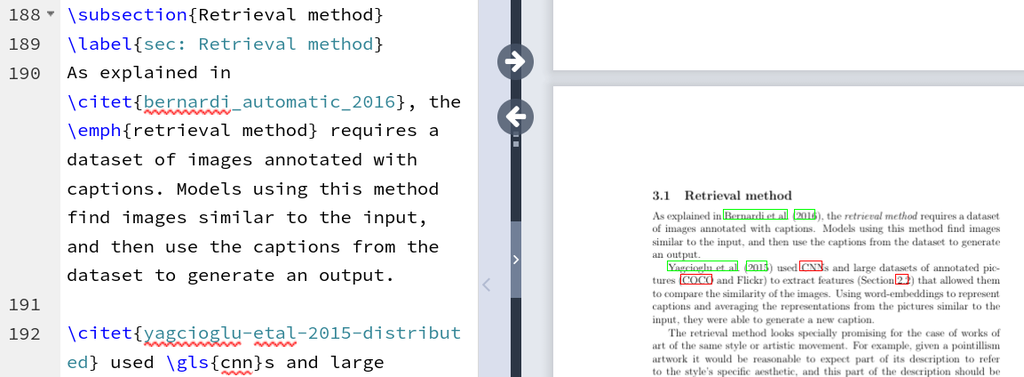

To the left there’s the code and to the right there’s the generated document.

If you have not used it before you may ask yourself why go through so much trouble to write a document? Why not just use Microsoft Word or Google Docs?

The worlds of research, developement, and academia use LaTeX for writing documents and you too will be expected to write your reports, posters, and slides on LaTeX.

Why? Beyond being open software, LaTeX is like another Swiss knife: it allows you to do anything you’d ever want in a document: Automatic formatting of citation formats, cross references, mathematical symbols, bibliography management, and much more.

There will be a couple of tutorials during the first semester for learning to use $\LaTeX$. Most people create a free account in [Overleaf](https://www.overleaf.com/) in order to avoid installing $\LaTeX$ locally.

## 6. Strategic attendance

You will find that there are just too many courses, lectures, projects, presentations, and deadlines in the first semester. This rythm is **not** healthy.

> avoid burnout

Ideally you’d find time to do other things, but with this schedule it is just not realistic. An option is to attend to the lectures strategically. If you already know a topic, then maybe you can skip the morning lecture and get 30 more minutes of sleep that will make your day better, or simply allow you to rest.

## 7. Stack Exchange

[Stack Exchange](https://stackexchange.com/) is a website where people ask questions, generally about programming, and get other users to answer.

> Everyone uses Stack Exchange even for the most simple things, so don’t hesitate to use it

Yep, most programmers just google what they want to do, like this:

```
"<your programming task> stack exchange"
```

and the search results will be full of other people who had the same problem and asked for help online.

[figure not shown]

## 8. Git

Git is a tool for managing changes in a document.

You’ve probably seem people writing a report and then making notifications by copying files and naming them like this: “report.docx”, “report_v2.docx”, “report_FINAL.docx”, “report_FINAL_v2.docx”, etc.

Git exists to avoid doing that. With git all the changes in any kind of file can be tracked, undone, merged with changes from other people, etc. It is a basic tool for any programming project.

It is however, somewhat tricky to use. I do not understand how it works, even partially, but it has saved my code from getting disordered many times.

There will be some sessions in the first semester to learn Git.

[figure not shown]

## Have other activities!

[figure not shown]